# Introduction to PHRM3301

Adam La Caze

Semester 1, 2024

# Objectives, Set-up and Expectations

## PHRM3031 Objectives

1. Explain the methods used to ensure rigour in the study designs employed in clinical epidemiology
2. Evaluate the evidence provided by systematic reviews, meta-analyses, randomized trials, cohort studies and case-control studies
3. Synthesise evidence from diverse sources to inform evidence-based decisions regarding patient care and public health (including treatment, screening, prevention and health service delivery)
4. Identify how practitioners can make errors when reasoning about clinical evidence
5. Develop and implement a project that takes into consideration study design, methodology, data analysis and research ethics
6. Justify inferences from collected data by employing statistical methods
7. Communicate insights from data as evidence within a given context for both a professional and lay audience

## Course set-up

- The course is team-taught between the School of Pharmacy and the School of Mathematics and Physics

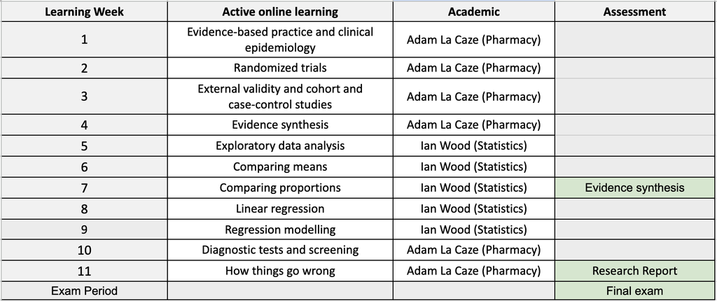

- PHRM3301 is a 2-unit course. You should expect to spend approximately 10 hours a week on the course

| Components | Hours/week (approx) |
| --- | --- |
| Active online learning (UQ Extend) | 4–6 |
| In-person workshops | 2 |
| Assessment | 2–4 |

## Approaching the course

**Active online learning**

- Use the activities as learning activities *and* as feedback on how you are travelling
- Being able to read, interpret and apply clinical research is a key objective of the course

**Workshops**

- Attend in person (recorded, but these are a secondary resource)
- Complete the active online learning activities *prior* to the workshop

## Timetable

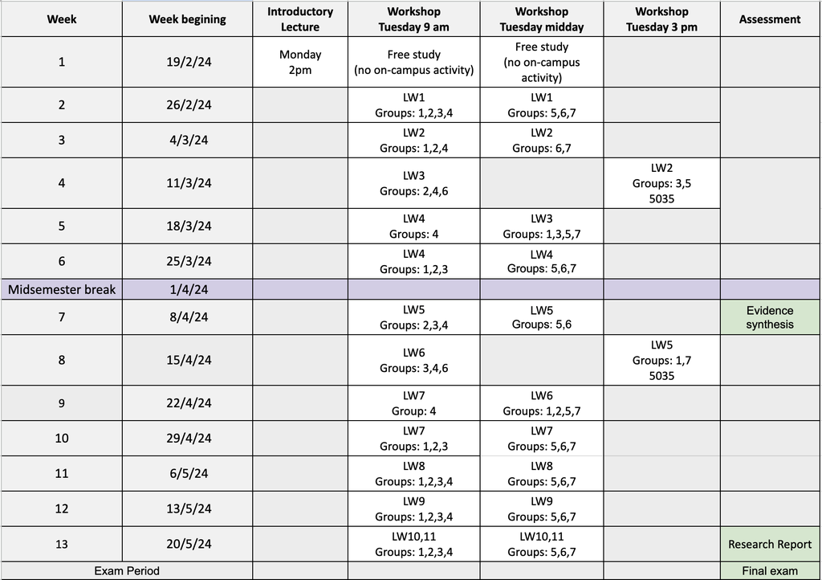

## Course Resources

**Blackboard**

information, assessment submission regarding the course (workshops assessment)

**Electronic Course Profile (ECP)**

information on assessment and rules.

**[UQ Extend](https://extend.uq.edu.au/courses/course-v1:UQ+PHRM3301+7420_20026/course/)**

Active online learning activities

**[Ed Discussion Board](https://edstem.org/au/courses/14804/discussion/)**

use Ed Discussion Board for all questions and discussion related to the course

**[Reading List](https://rl.talis.com/3/uq/lists/06B79DFC-21A2-F9E4-D92B-305F03152F39.html?lang=en)**

central reading list for course resources and RiPPLE activity

**[R](https://www.r-project.org/)**

a free online (and powerful) statistical software environment. You will use R in the statistics component of the course. Consider getting familiar with the program prior to LW5.

## Expectations

- Participate in in-person workshops and in the discussion board
- Come to the workshops with any questions you have from the week’s learning activities

## What you can expect from me

- Clarity about learning objectives and assessment. If something is not clear post your question to the course discussion board
- Workshops will have a worksheet and will be recorded. Worksheets will be on Blackboard
- The course is set up to provide feedback and help you to progressively develop skills

# Assessment

## Evidence synthesis (LW1–4)

- You will receive a published randomized trial by Week 4 and your assignment is due in Week 7.
- The assignment is worth 30% of the grade
- The rubric used to assess the assignment is available on Blackboard and the ECP.
- Word limit 1500 words

## Engagement tasks (LW5–9) (Statistics)

- Five engagement tasks will be set over the 5 learning weeks.
- These ongoing engagement activities occur in relation to the statistics component of the course (Learning Weeks 5–9).
- These assessment tasks may include (but are not limited to) online quizzes and completion of problem sets related to the learning objectives in the relevant weeks.
- Further detail will be on Blackboard shortly

## Research Report (Statistics)

- Identify a research question that can be answered within the “Islands” simulation.
- Develop methods to collect and analyse the data and then present the results with conclusions.
- This is a group inquiry-based research task (groups of 3 students).
- Communicate your study design, results and conclusions in a short structured research paper.
- The assignment is worth 30% of the grade

## Written Exam

- When: the written exam is held in the exam period at the end of the semester
- Duration: 2 hours (10 minutes reading time)
- Range of different question types: MCQ, multiple answer, short answer, problem solving
- Content: is taken material throughout all of the course
- I will have a sample exam available by Week 10. (If you want something earlier, see recent exam papers from PHRM3031 and the statistics component of PHRM1020)

The exam is an on-campus invigilated exam using [Inspera](https://web.library.uq.edu.au/library-services/it/learnuq-blackboard-help/inspera-assessment)

## Grades

| Assessment | Due | Weight |
| --- | --- | --- |
| Evidence synthesis | 12 April | 30% |
| Engagement tasks (LW5–9) | LW5–9 | 10% |
| Research report | 20 May | 30% |
| Written exam | Exam period | 30% |

To pass PHRM3301 you need to achieve a **total mark $\ge$ 50%**

Questions?

Comments?